# Economic Vulerability variables PCA

Cong Cong

7/18/2019

# PCA on ACS data based on Census Tract

```r
data <- read.csv("./data/working/ACS_final_index_2/07_11_2019_joined_acs_final.csv") %>% filter(id_type=="census_tract") %>% select (-c(X, X.x, id, id_type, X.y)) %>% na.omit()

#PCA with standadization
pr.data <- PCA(data, scale.unit = TRUE, graph = FALSE)
```

##Identify Dimensions ###Number of principle components One way to determine the number of factors or components in a data matrix is to examine the scree plot of the successive eigenvalues. Sharp breaks in the plot suggest the appropriate number of components or factors to extract. The scree plot below shows ~45% of the variances contained in the data are retained by the first principal component. The elbow is between the first and the second dimensions.

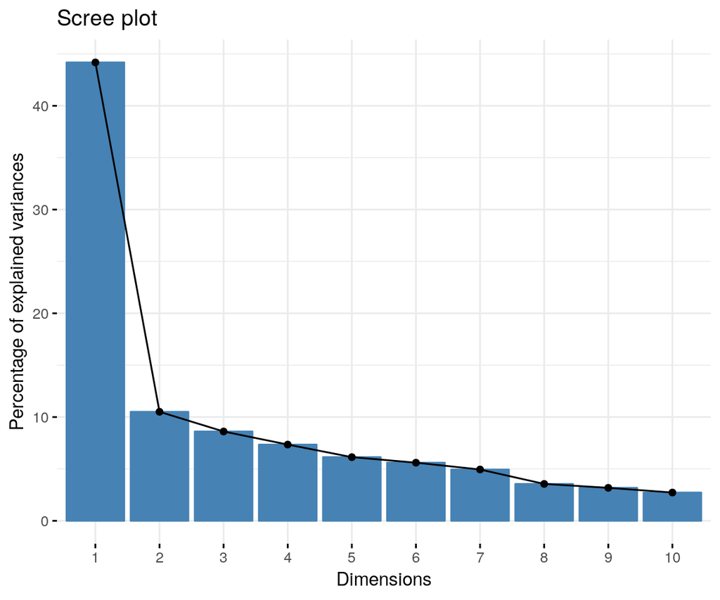

```r
fviz_screeplot(pr.data, ncp=10)
```

Parallel analyis compares the scree of factors of the observed data with that of a random data matrix of the same size as the original. The parallel analysis for this dataset indicates that two components should be retained. There are two ways to tell this; (1) two of the eigenvalues in the actual data are greater than the simulated/resampled data (though marginal for the second eigenvalue), and (2) the dashed line for parallel analysis in the graph crosses the blue line before reaching the third component.

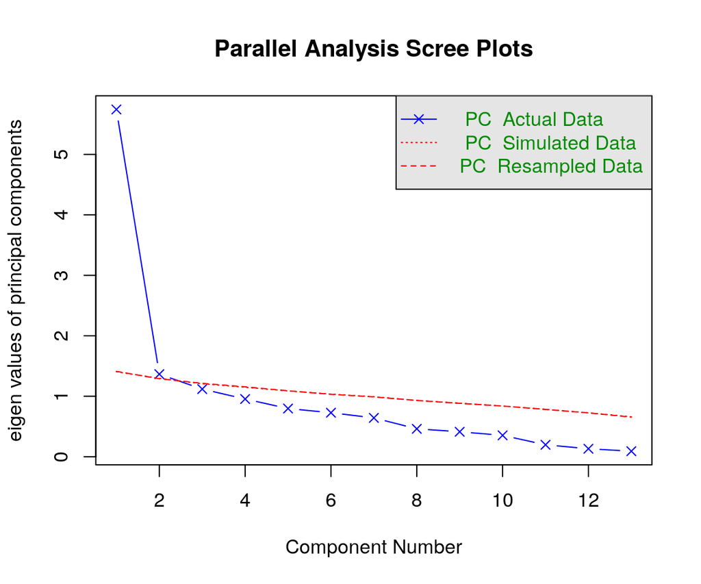

```
## Parallel analysis suggests that the number of factors =  NA  and the number of components =  2
```

```r
psych::fa.parallel(data,fa="pc")
```

###Variances explained by the principal components The proportion of variances retained by the principal components can be extracted as follows. ~55% of variance is explained by the first two pricipal components.

```r
eigenvalues <- pr.data$eig
head(eigenvalues)
```

```
##        eigenvalue percentage of variance cumulative percentage of variance
## comp 1  5.7432288              44.178683                          44.17868
## comp 2  1.3655717              10.504398                          54.68308
## comp 3  1.1187356               8.605659                          63.28874
## comp 4  0.9547252               7.344040                          70.63278
## comp 5  0.7973111               6.133162                          76.76594
## comp 6  0.7280258               5.600198                          82.36614
```

##Dimension description ###Variables correlated with the principal components The variables can be plotted as points in the component space using their loadings (correlation between a variable and a PC) as coordinates.

```r
head(pr.data$var$coord)
```

```
##                              Dim.1       Dim.2       Dim.3       Dim.4
## pai_pct                 0.39915482 -0.05596950  0.34329400  0.68575107
## ssi_pct                 0.43424626 -0.21076932  0.38797300  0.35160252
## unenrolled_pct          0.03575591  0.85954657  0.06393445  0.01405983
## poverty_pct             0.80024685  0.08889131 -0.05232623 -0.11474969
## no_hicov_pct            0.93145335  0.04183201 -0.00705566 -0.13879603
## over_30min_commute_pct -0.08237368 -0.21369933  0.77114774 -0.44659660
##                              Dim.5
## pai_pct                -0.34913765
## ssi_pct                 0.56691644
## unenrolled_pct          0.31013110
## poverty_pct             0.03017437
## no_hicov_pct           -0.09784446
## over_30min_commute_pct  0.12570116
```

Variables that are correlated with PC1 and PC2 are the most important in explaining the variability in the data set. Correlation circle projects the features/variables of the data into the space of the first two dimensions. The angle shows the correlation between variables. Again, most variables are positively correlated with the first dimension.

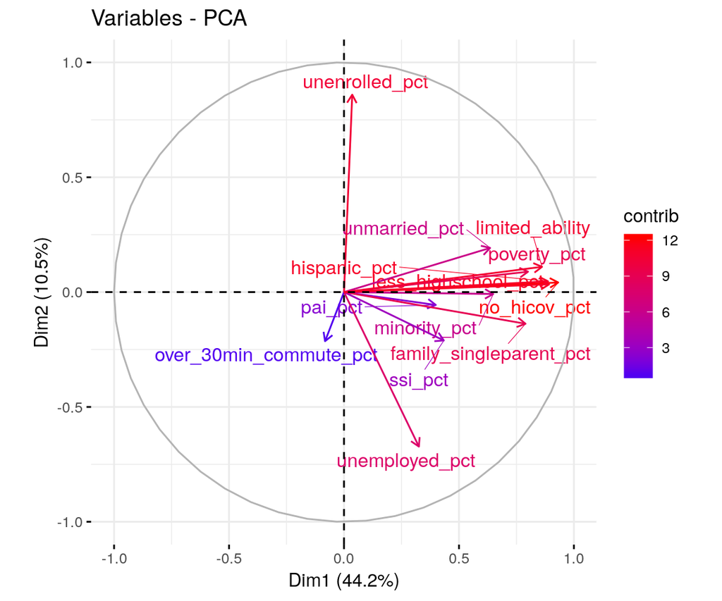

```r
fviz_pca_var(pr.data, col.var="contrib",repel = TRUE)+
  scale_color_gradient2(low="white", mid="blue",
                      high="red")
```

The following four variables have strong positive correlation (>~0.85) with Dimension 1:  
- percentage of households with no health insurance coverage (no_hicov_pct)  
- percentage of population with less than highschool education (less_highschool_pct)  
- percentage of Hispanic population (hispanic_pct)  
- percentage of households with limited English ability (limited_ability)